# PCIT-CoS-Waitlist RCT Paper 1: BITSEA Competence, Controlling for ASD

Nancy Briggs

05 JAN 2021

### BITSEA Competence Adjusting for ASD

#### Descriptives

| asdcase | group | time | n | mean | sd | median | min | max |
| --- | --- | --- | --- | --- | --- | --- | --- | --- |
| 0 | 1 | 1 | 23 | 1.407 | 0.300 | 1.455 | 0.727 | 1.909 |
| 0 | 1 | 2 | 19 | 1.627 | 0.229 | 1.636 | 1.091 | 2.000 |
| 0 | 1 | 3 | 13 | 1.678 | 0.242 | 1.636 | 1.364 | 2.091 |
| 0 | 2 | 1 | 24 | 1.515 | 0.181 | 1.545 | 1.182 | 1.818 |
| 0 | 2 | 2 | 11 | 1.536 | 0.307 | 1.636 | 1.091 | 1.909 |
| 0 | 2 | 3 | 5 | 1.569 | 0.208 | 1.545 | 1.300 | 1.818 |
| 0 | 3 | 1 | 22 | 1.478 | 0.264 | 1.455 | 0.909 | 1.909 |
| 0 | 3 | 2 | 19 | 1.459 | 0.241 | 1.455 | 1.000 | 1.818 |
| 0 | 3 | 3 | 0 | NaN | NA | NA | Inf | -Inf |
| 1 | 1 | 1 | 6 | 1.061 | 0.280 | 1.091 | 0.636 | 1.455 |
| 1 | 1 | 2 | 5 | 1.175 | 0.477 | 1.364 | 0.364 | 1.600 |
| 1 | 1 | 3 | 5 | 1.073 | 0.562 | 1.273 | 0.182 | 1.636 |
| 1 | 2 | 1 | 3 | 0.909 | 0.157 | 0.818 | 0.818 | 1.091 |
| 1 | 2 | 2 | 2 | 1.318 | 0.193 | 1.318 | 1.182 | 1.455 |
| 1 | 2 | 3 | 0 | NaN | NA | NA | Inf | -Inf |
| 1 | 3 | 1 | 4 | 1.114 | 0.388 | 1.136 | 0.636 | 1.545 |
| 1 | 3 | 2 | 2 | 0.864 | 0.579 | 0.864 | 0.455 | 1.273 |
| 1 | 3 | 3 | 0 | NaN | NA | NA | Inf | -Inf |

[figure not shown]

#### Model & Results

A linear mixed model with random effect for individual and fixed effects of group, time and the interaction was run. ASD status was then entered into the model as a main effect and then the 3-way interaction. Estimated marginal means were obtained, and contrasts specified to test Hypothesis 1 and Hypothesis 2.

```
## fixed-effect model matrix is rank deficient so dropping 1 column / coefficient
```

```
## fixed-effect model matrix is rank deficient so dropping 3 columns / coefficients
```

```
## refitting model(s) with ML (instead of REML)
```

|  | Effect | npar | AIC | BIC | logLik | deviance | Chisq | Df | Pr(>Chisq) |
| --- | --- | --- | --- | --- | --- | --- | --- | --- | --- |
| result0 | Intercept | 3 | 33.597 | 42.878 | -13.798 | 27.597 | NA | NA | NA |
| result0_5 | ASD | 4 | 10.160 | 22.535 | -1.080 | 2.160 | 25.437 | 1 | 0.000 |
| result1 | Group* Time*ASD | 6 | 13.890 | 32.452 | -0.945 | 1.890 | 0.270 | 2 | 0.874 |
| result2 | ASD + Group + Time | 8 | 6.463 | 31.213 | 4.769 | -9.537 | 11.427 | 2 | 0.003 |
| result3 | ASD + Group + Time + Group*Time | 11 | 6.840 | 40.872 | 7.580 | -15.160 | 5.622 | 3 | 0.131 |
| result4 | Group* Time*ASD | 17 | 9.304 | 61.897 | 12.348 | -24.696 | 9.537 | 6 | 0.146 |

There is no evidence that ASD moderates the 2-way group*time interaction (the 3-way interaction p=0.146).

Model3, the model with Group*Time, adjusted by ASD will be the model I use for Estimated Means.

```r
summary(result3)
```

```
## Linear mixed model fit by REML. t-tests use Satterthwaite's method [
## lmerModLmerTest]
## Formula: outcome ~ asdcase + group * time + (1 | id)
##    Data: dat
##
## REML criterion at convergence: 20.6
##
## Scaled residuals:
##      Min       1Q   Median       3Q      Max
## -2.22526 -0.45381  0.09713  0.50162  1.68662
##
## Random effects:
##  Groups   Name        Variance Std.Dev.
##  id       (Intercept) 0.05285  0.2299
##  Residual             0.02531  0.1591
## Number of obs: 163, groups:  id, 83
##
## Fixed effects:
##               Estimate Std. Error        df t value Pr(>|t|)
## (Intercept)    1.42457    0.05442  98.80406  26.178  < 2e-16 ***
## asdcase1      -0.43087    0.07887  75.37588  -5.463 5.79e-07 ***
## group2         0.07112    0.07514 101.09570   0.946 0.346195
## group3         0.05831    0.07530 102.70183   0.774 0.440512
## time2          0.16034    0.04528  77.82054   3.541 0.000676 ***
## time3          0.14793    0.05044  79.17057   2.933 0.004393 **
## group2:time2  -0.08574    0.07495  83.45734  -1.144 0.255930
## group3:time2  -0.15463    0.06680  79.24377  -2.315 0.023216 *
## group2:time3  -0.04057    0.10240  84.28784  -0.396 0.692965
## ---
## Signif. codes:  0 '***' 0.001 '**' 0.01 '*' 0.05 '.' 0.1 ' ' 1
##
## Correlation of Fixed Effects:
##             (Intr) asdcs1 group2 group3 time2  time3  grp2:2 grp3:2
## asdcase1    -0.300
## group2      -0.689  0.101
## group3      -0.675  0.059  0.482
## time2       -0.354 -0.001  0.256  0.256
## time3       -0.311 -0.022  0.228  0.228  0.436
## group2:tim2  0.218 -0.014 -0.323 -0.155 -0.604 -0.263
## group3:tim2  0.233  0.024 -0.171 -0.373 -0.678 -0.296  0.409
## group2:tim3  0.150  0.023 -0.233 -0.112 -0.215 -0.493  0.340  0.146
## fit warnings:
## fixed-effect model matrix is rank deficient so dropping 1 column / coefficient
```

#### Estimated Means & Change

Estimated means for each Treatment and Time (adjusted by ASD status) are presented. In addition, within-group change between time points is presented with 95% CIs.

##### Group mean difference at each timepoint

Effect sizes all calculated by the pooled T1 SD of the outcome. Adjusted p-value from Bonferroni correction.

Group Differences at Each Time Point

| Group Difference | Time | Mean | SE | t | p | adj p | Lower CL | Upper CL | Effect Size | Lower CL | Upper CL |
| --- | --- | --- | --- | --- | --- | --- | --- | --- | --- | --- | --- |
| 1 - 2 | 1 | -0.071 | 0.075 | -0.946 | 0.612 | 1.000 | -0.250 | 0.108 | -0.240 | -0.850 | 0.206 |
| 1 - 3 | 1 | -0.058 | 0.075 | -0.774 | 0.720 | 1.000 | -0.237 | 0.121 | -0.197 | -0.768 | 0.376 |
| 2 - 3 | 1 | 0.013 | 0.077 | 0.167 | 0.985 | 1.000 | -0.169 | 0.195 | 0.043 | -0.447 | 0.656 |
| 1 - 2 | 2 | 0.015 | 0.088 | 0.167 | 0.985 | 1.000 | -0.193 | 0.222 | 0.049 | -0.688 | 0.494 |
| 1 - 3 | 2 | 0.096 | 0.080 | 1.205 | 0.453 | 0.692 | -0.093 | 0.286 | 0.326 | -0.366 | 0.764 |
| 2 - 3 | 2 | 0.082 | 0.089 | 0.916 | 0.631 | 1.000 | -0.130 | 0.293 | 0.276 | -0.392 | 0.914 |
| 1 - 2 | 3 | -0.031 | 0.112 | -0.272 | 0.960 | 1.000 | -0.296 | 0.235 | -0.103 | -0.908 | 0.461 |
| 1 - 3 | 3 | NA | NA | NA | NA | NA | NA | NA | NA | NA | NA |
| 2 - 3 | 3 | NA | NA | NA | NA | NA | NA | NA | NA | NA | NA |

* Effect size scaled by pooled T1 SD  
† ES 95% Bootstrapped Percentile CI limits  
‡ If you want a positive ES (and it is calculated as negative), be sure to switch the signs and positions of the lower and upper CIs.

##### Change within each group

Within-Group Change and Effect Sizes

| Change | Group | Mean | SE | t | p | adj p | Lower CL | Upper CL | Effect Size | Lower CL | Upper CL |
| --- | --- | --- | --- | --- | --- | --- | --- | --- | --- | --- | --- |
| 1 - 2 | 1 | -0.160 | 0.045 | -3.538 | 0.002 | 0.002 | -0.269 | -0.052 | -0.542 | -0.769 | -0.177 |
| 1 - 3 | 1 | -0.148 | 0.051 | -2.928 | 0.012 | 0.013 | -0.269 | -0.027 | -0.500 | -0.772 | -0.121 |
| 2 - 3 | 1 | 0.012 | 0.051 | 0.243 | 0.968 | 1.000 | -0.110 | 0.134 | 0.042 | -0.248 | 0.364 |
| 1 - 2 | 2 | -0.075 | 0.060 | -1.245 | 0.430 | 0.649 | -0.217 | 0.068 | -0.252 | -0.613 | 0.120 |
| 1 - 3 | 2 | -0.107 | 0.089 | -1.201 | 0.456 | 0.699 | -0.321 | 0.106 | -0.363 | -0.922 | 0.149 |
| 2 - 3 | 2 | -0.033 | 0.091 | -0.359 | 0.931 | 1.000 | -0.250 | 0.185 | -0.111 | -0.751 | 0.406 |
| 1 - 2 | 3 | -0.006 | 0.049 | -0.116 | 0.993 | 1.000 | -0.123 | 0.112 | -0.019 | -0.346 | 0.218 |
| 1 - 3 | 3 | NA | NA | NA | NA | NA | NA | NA | NA | NA | NA |
| 2 - 3 | 3 | NA | NA | NA | NA | NA | NA | NA | NA | NA | NA |

* Effect size scaled by pooled T1 SD  
† ES 95% Bootstrapped Percentile CI limits  
‡ If you want a positive ES (and it is calculated as negative), be sure to switch the signs and positions of the lower and upper CIs.

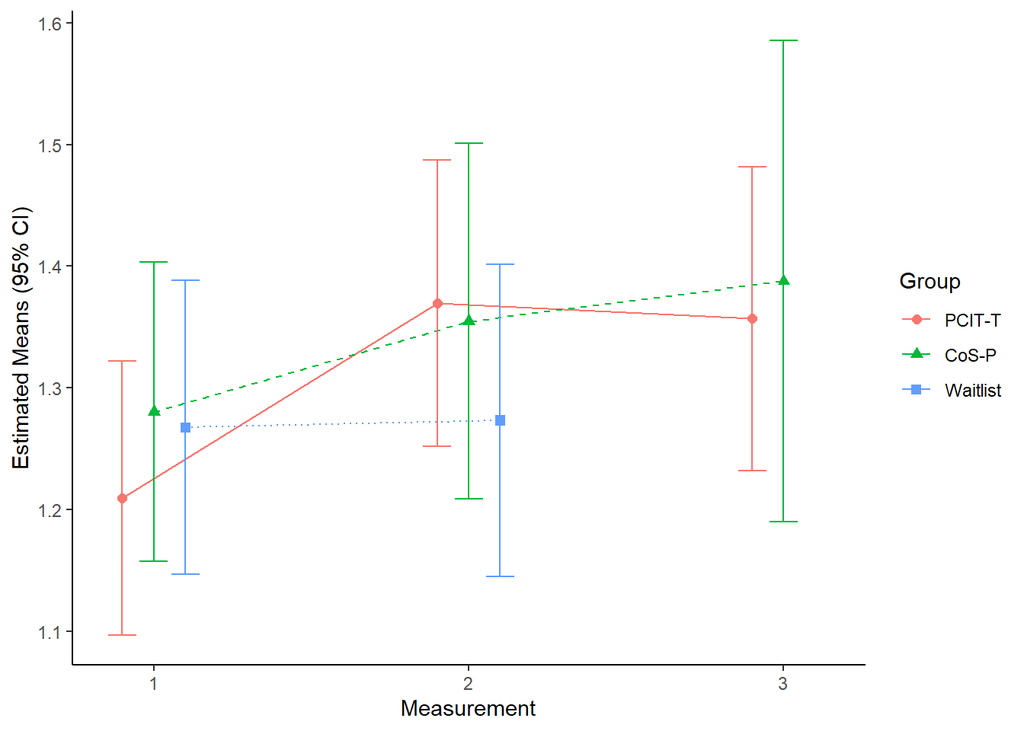

#### Hypothesis 1

We hypothesize that from baseline (‘T1’) to post-treatment/waitlist (‘T2’) there will be a gradient effect, whereby parent-child dyads who receive PCIT-T will show the greatest gains and parent-child dyads who receive no treatment will show the least gains. For the outcome, then, the null hypothesis is:

$H_0: \text {mean change}(\text{PCIT-T}) = \text {mean change}(\text{CoS-P}) = \text {mean change}(\text{Waitlist})$ $H_A: \text {mean change}(\text{PCIT-T}) > \text {mean change}(\text{CoS-P}) > \text {mean change}(\text{Waitlist})$

This is a joint hypothesis test.

First, confirming that the ordering of the means is as hypothesized:

```
## group = 1:
##  contrast estimate     SE   df t.ratio p.value
##  1 - 2    -0.16034 0.0453 79.5  -3.538  0.0019
##  1 - 3    -0.14793 0.0505 80.9  -2.928  0.0122
##  2 - 3     0.01242 0.0511 77.7   0.243  0.9679
##
## group = 2:
##  contrast estimate     SE   df t.ratio p.value
##  1 - 2    -0.07461 0.0599 88.6  -1.245  0.4302
##  1 - 3    -0.10736 0.0894 87.8  -1.201  0.4560
##  2 - 3    -0.03275 0.0911 81.5  -0.359  0.9313
##
## group = 3:
##  contrast estimate     SE   df t.ratio p.value
##  1 - 2    -0.00572 0.0492 82.2  -0.116  0.9926
##  1 - 3      nonEst     NA   NA      NA      NA
##  2 - 3      nonEst     NA   NA      NA      NA
##
## Results are averaged over the levels of: asdcase
## Degrees-of-freedom method: kenward-roger
## P value adjustment: tukey method for comparing a family of 3 estimates
```

Ordering of effects are in the hypothesized, order: PCITT>COSP>Waitlist

```
##   (Intercept) asdcase1 group2 group3 time2 time3 group2:time2 group3:time2
## 1           0        0      0      0     0     0           -1            0
## 2           0        0      0      0     0     1            0            1
##   group2:time3
## 1            0
## 2            0
```

```
##
##   General Linear Hypotheses
##
## Linear Hypotheses:
##         Estimate
## 1 == 0  0.085735
## 2 == 0 -0.006698
##
## Global Test:
##        F DF1 DF2 Pr(>F)
## 1 0.6634   2 152 0.5166
```

#### Hypothesis 2

There will be a gradient of size of change from T2 to T3 such that the change in the PCIT-T group > the change in the CoS-P group. This isn’t really a gradient; it’s just 1 hypothesis.

First, the change in PCITT and COSP from time 2 to time 3:

```
## group = 1:
##  contrast estimate     SE   df t.ratio p.value
##  1 - 2    -0.16034 0.0453 79.5  -3.538  0.0019
##  1 - 3    -0.14793 0.0505 80.9  -2.928  0.0122
##  2 - 3     0.01242 0.0511 77.7   0.243  0.9679
##
## group = 2:
##  contrast estimate     SE   df t.ratio p.value
##  1 - 2    -0.07461 0.0599 88.6  -1.245  0.4302
##  1 - 3    -0.10736 0.0894 87.8  -1.201  0.4560
##  2 - 3    -0.03275 0.0911 81.5  -0.359  0.9313
##
## group = 3:
##  contrast estimate     SE   df t.ratio p.value
##  1 - 2    -0.00572 0.0492 82.2  -0.116  0.9926
##  1 - 3      nonEst     NA   NA      NA      NA
##  2 - 3      nonEst     NA   NA      NA      NA
##
## Results are averaged over the levels of: asdcase
## Degrees-of-freedom method: kenward-roger
## P value adjustment: tukey method for comparing a family of 3 estimates
```

```
##
##   Simultaneous Tests for General Linear Hypotheses
##
## Fit: lmer(formula = outcome ~ asdcase + group * time + (1 | id), data = dat)
##
## Linear Hypotheses:
##        Estimate Std. Error z value Pr(>|z|)
## 1 == 0  0.04516    0.10430   0.433    0.665
## (Adjusted p values reported -- single-step method)
```

p>0.05.

#### Residuals

Assumptions of the model are met.

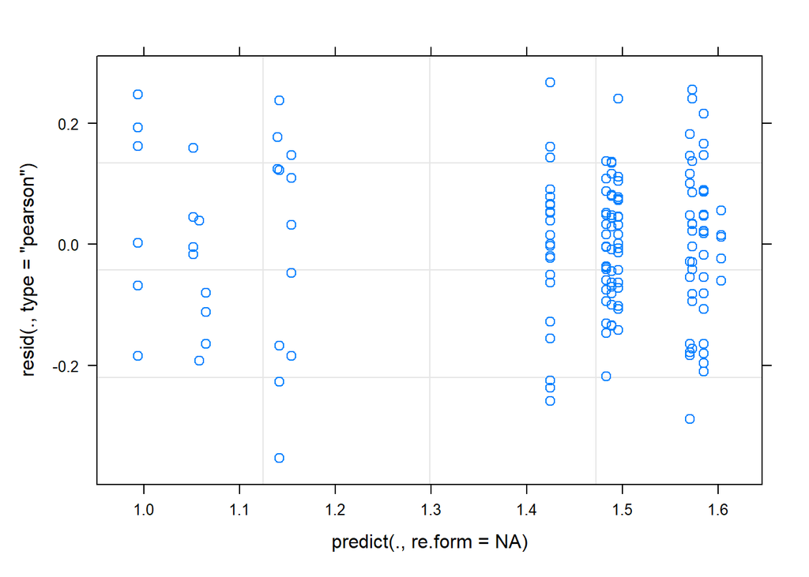

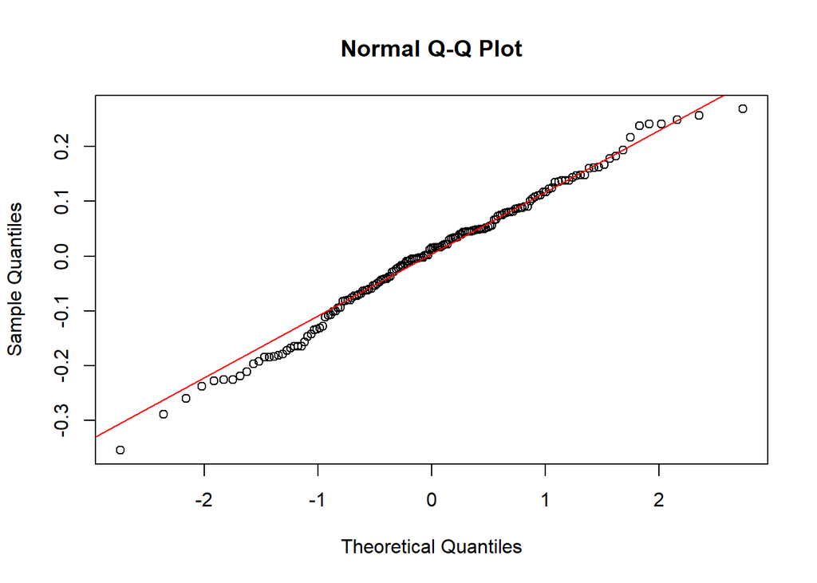

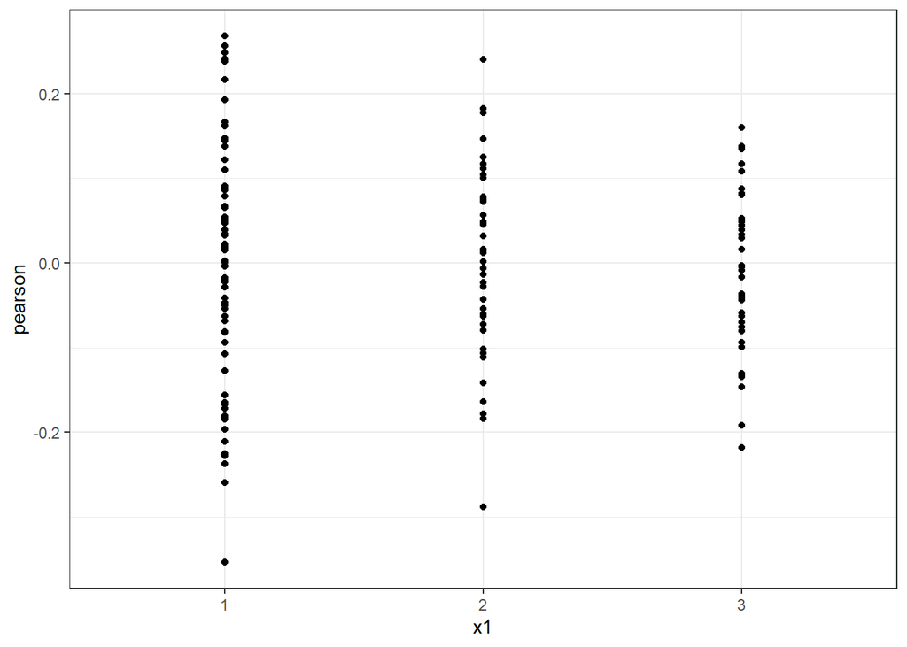

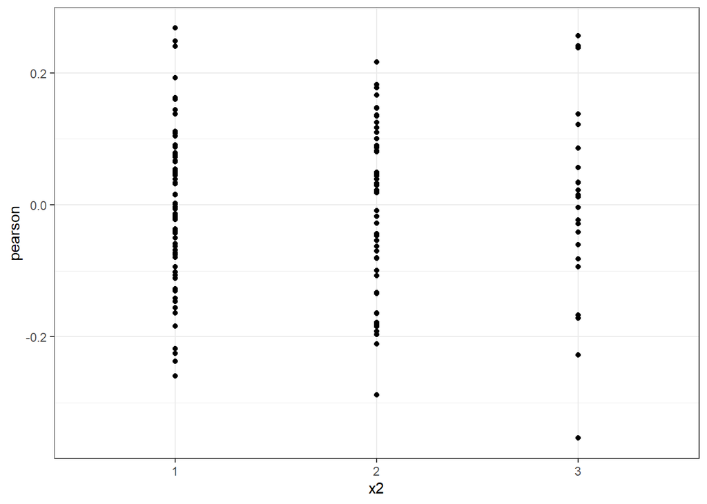

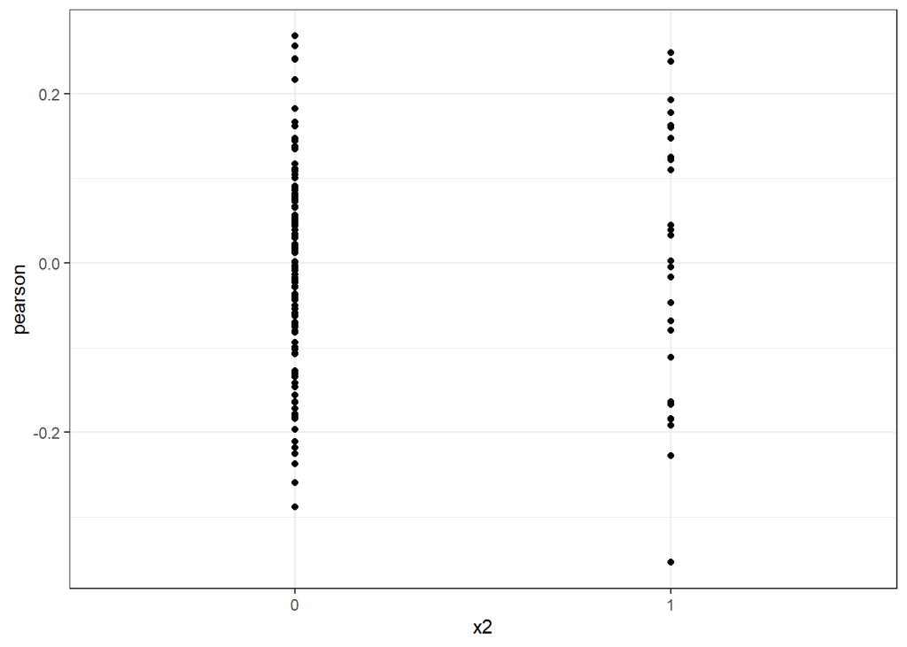

```r
rm(list = ls())
```